# The Silent Workforce: Child Labour Around the World

A UNICEF Data Story | BAA1030 Data Analytics

Author

Satwika Salveru | A00048014

Published

April 14, 2026

## 1 Introduction

> *“The test of the morality of a society is what it does for its children.”* — Dietrich Bonhoeffer

**Child labour** is one of the most serious and persistent human rights violations of our time. Despite decades of global progress, **millions of children aged 5 to 17** continue to be deprived of their childhood, their potential, and their dignity — forced into work that harms their physical and mental development.

According to **UNICEF**, child labour is defined as work that exceeds acceptable limits and compromises a child’s education, health, and future. It is not a distant or historical problem — it is happening **right now**, across dozens of countries, affecting families trapped in cycles of poverty with no visible way out.

This report tells that story through data. Using UNICEF’s global child labour dataset alongside World Bank economic indicators, we explore:

- 🌍 **Where** child labour is most concentrated globally
- 📊 **Which** countries bear the heaviest burden
- 💰 **How** economic development connects to child protection
- 📈 **Whether** the situation is improving over time

> **Key Fact:** In some of the worst-affected countries, nearly **1 in 2 children** is engaged in labour — robbing them of education and a better future.

## 2 Data and Methodology

This analysis draws from two UNICEF datasets:

| Dataset | Description |
| --- | --- |
| `unicef_indicator_1.csv` | Percentage of children (5-17 years) engaged in child labour |
| `unicef_metadata.csv` | Country-level indicators: GDP, life expectancy, population |

**Tools used:** Python · pandas · plotnine · geopandas

## 3 Data Setup

**Load libraries, import data, clean and transform**

```python
import pandas as pd
import numpy as np
from plotnine import *
import geopandas as gpd
import warnings
warnings.filterwarnings("ignore")

# Load datasets
indicator = pd.read_csv("unicef_indicator_1__1_.csv")
metadata  = pd.read_csv("unicef_metadata__1_.csv")

# Data quality check
print("=== Indicator Dataset ===")
print(f"Rows: {indicator.shape[0]} | Countries: {indicator['country'].nunique()}")
print(f"Years: {indicator['time_period'].min()} to {indicator['time_period'].max()}")
print(f"Child labour range: {indicator['obs_value'].min():.1f}% to {indicator['obs_value'].max():.1f}%")

# Most recent observation per country
latest = (
    indicator
    .sort_values("time_period", ascending=False)
    .drop_duplicates(subset="alpha_3_code")
    [["country", "alpha_3_code", "obs_value", "time_period"]]
    .rename(columns={"obs_value": "child_labour_pct"})
    .reset_index(drop=True)
)

# Latest GDP and life expectancy per country
gdp_latest = (
    metadata
    .dropna(subset=["GDP per capita (constant 2015 US$)"])
    .sort_values("year", ascending=False)
    .drop_duplicates(subset="alpha_3_code")
    [["alpha_3_code", "GDP per capita (constant 2015 US$)",
      "Life expectancy at birth, total (years)", "Population, total"]]
    .rename(columns={
        "GDP per capita (constant 2015 US$)": "gdp_pc",
        "Life expectancy at birth, total (years)": "life_exp",
        "Population, total": "population"
    })
    .reset_index(drop=True)
)

print(f"\nCountries with child labour data: {len(latest)}")
print(f"Countries with GDP data: {len(gdp_latest)}")
```

```
=== Indicator Dataset ===
Rows: 306 | Countries: 102
Years: 2010 to 2023
Child labour range: 0.1% to 58.9%

Countries with child labour data: 102
Countries with GDP data: 208
```

## 4 World Map — Where Is Child Labour Happening?

> *Child labour is not a localised issue; it is a global crisis affecting millions. This map reveals the hotspots of vulnerability. You can see that the highest concentrations of child labour are found in sub-Saharan Africa and parts of South Asia. By looking at the map, we identify where the need for intervention is most urgent — these are not random patterns, but regions defined by deep structural poverty and limited social safety nets.*

**World map**

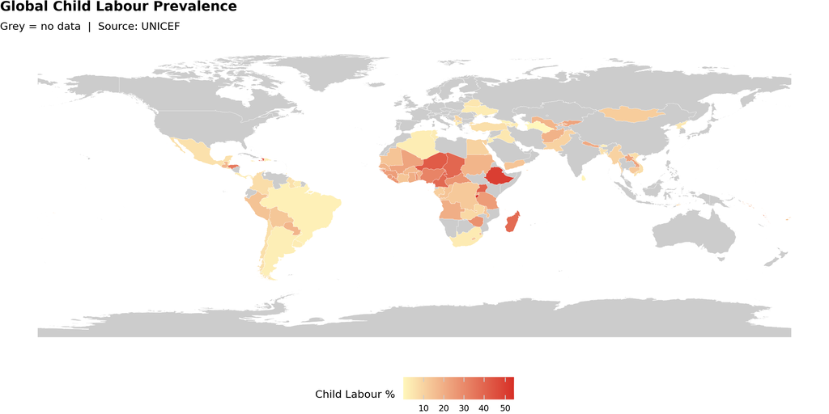

Child labour prevalence by country

```python
world_url = "https://raw.githubusercontent.com/datasets/geo-countries/master/data/countries.geojson"
world_countries = gpd.read_file(world_url)

iso_col = [c for c in world_countries.columns if "ISO" in c.upper()]
merge_col = iso_col[0] if iso_col else world_countries.columns[1]

map_df = world_countries.merge(
    latest, left_on=merge_col, right_on="alpha_3_code", how="left"
)
map_df["child_labour_pct"] = pd.to_numeric(map_df["child_labour_pct"], errors="coerce")

(
    ggplot(map_df)
    + geom_map(aes(fill="child_labour_pct"), color="white", size=0.1)
    + scale_fill_gradient(
        low="#fff7bc", high="#d73027",
        na_value="#cccccc",
        name="Child Labour %"
    )
    + labs(
        title="Global Child Labour Prevalence",
        subtitle="Grey = no data  |  Source: UNICEF"
    )
    + theme_void()
    + theme(
        plot_title=element_text(size=14, weight="bold"),
        legend_position="bottom",
        figure_size=(12, 6)
    )
)
```

## 5 Top 20 Countries — Bar Chart

> *The numbers behind the map — which countries are most affected, and by how much?*

The bar chart below ranks the **20 countries with the highest child labour rates**. Each bar represents the most recent survey year available for that country. The gradient colouring visually separates the most severe cases from the rest. Notice how the top countries are almost entirely from **Sub-Saharan Africa** — a reflection of systemic economic and social inequality that demands targeted, region-specific policy responses. Several countries exceed **40%**, meaning nearly one in every two children is working instead of learning.

**Bar chart: highest child labour countries**

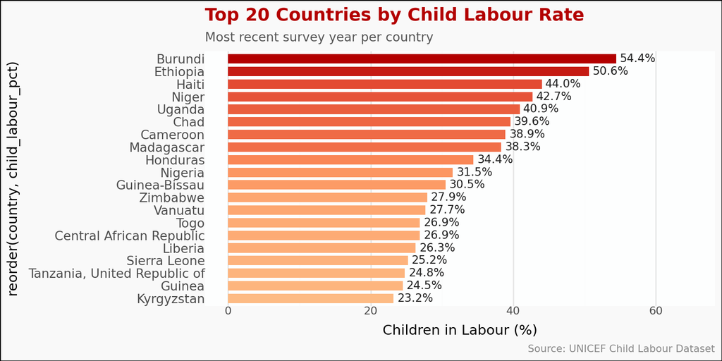

Top 20 countries ranked by child labour rate

```python
top20 = (
    latest
    .nlargest(20, "child_labour_pct")
    .sort_values("child_labour_pct", ascending=True)
)

(
    ggplot(top20, aes(
        x="reorder(country, child_labour_pct)",
        y="child_labour_pct",
        fill="child_labour_pct"
    ))
    + geom_bar(stat="identity", width=0.75)
    + geom_text(
        aes(label="child_labour_pct"),
        format_string="{:.1f}%",
        ha="left",
        size=9,
        nudge_y=0.5,
        color="#222222"
    )
    + coord_flip()
    + scale_fill_gradientn(
        colors=["#fdbb84","#fc8d59","#e34a33","#b30000"],
        name="Rate (%)"
    )
    + scale_y_continuous(limits=(0, 65))
    + labs(
        title="Top 20 Countries by Child Labour Rate",
        subtitle="Most recent survey year per country",
        x=None,
        y="Children in Labour (%)",
        caption="Source: UNICEF Child Labour Dataset"
    )
    + theme_minimal()
    + theme(
        plot_title=element_text(size=14, weight="bold", color="#b30000"),
        plot_subtitle=element_text(size=10, color="#555555"),
        plot_caption=element_text(size=8, color="#888888"),
        panel_grid_major_y=element_blank(),
        axis_text_y=element_text(size=10),
        legend_position="none",
        panel_background=element_rect(fill="#fdfefe"),
        plot_background=element_rect(fill="#f9f9f9"),
        figure_size=(8, 4)
    )
)
```

## 6 GDP vs Child Labour — Scatterplot

**Scatterplot with regression: GDP vs child labour**

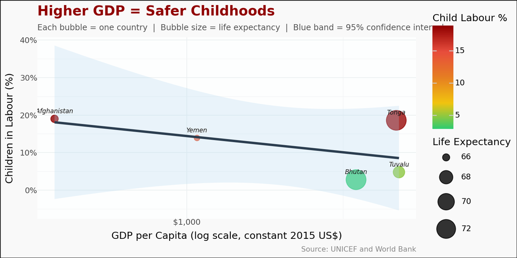

GDP per capita vs child labour rate with linear regression line

```python
scatter_df = (
    latest
    .merge(gdp_latest, on="alpha_3_code", how="inner")
    .dropna(subset=["gdp_pc", "child_labour_pct", "life_exp"])
)
scatter_df["log_gdp"] = np.log10(scatter_df["gdp_pc"])

# Label top 10 most affected countries
top_labels = scatter_df.nlargest(10, "child_labour_pct")

(
    ggplot(scatter_df, aes(x="log_gdp", y="child_labour_pct"))
    + geom_point(
        aes(size="life_exp", color="child_labour_pct"),
        alpha=0.8
    )
    + geom_smooth(
        method="lm",
        color="#2c3e50",
        fill="#aed6f1",
        alpha=0.25,
        size=1.5
    )
    + geom_text(
        data=top_labels,
        mapping=aes(label="country"),
        size=7,
        nudge_y=2.0,
        color="#1a1a1a",
        fontstyle="italic"
    )
    + scale_color_gradientn(
        colors=["#2ecc71","#f1c40f","#e67e22","#e74c3c","#900000"],
        name="Child Labour %"
    )
    + scale_size_continuous(name="Life Expectancy", range=(3, 12))
    + scale_x_continuous(
        breaks=[2, 3, 4, 5],
        labels=["$100","$1,000","$10,000","$100,000"]
    )
    + scale_y_continuous(
        breaks=[0, 10, 20, 30, 40, 50, 60],
        labels=["0%","10%","20%","30%","40%","50%","60%"]
    )
    + labs(
        title="Higher GDP = Safer Childhoods",
        subtitle="Each bubble = one country  |  Bubble size = life expectancy  |  Blue band = 95% confidence interval",
        x="GDP per Capita (log scale, constant 2015 US$)",
        y="Children in Labour (%)",
        caption="Source: UNICEF and World Bank"
    )
    + theme_minimal()
    + theme(
        plot_title=element_text(size=15, weight="bold", color="#900000"),
        plot_subtitle=element_text(size=9, color="#555555"),
        plot_caption=element_text(size=8, color="#888888"),
        panel_background=element_rect(fill="#fdfefe"),
        plot_background=element_rect(fill="#f9f9f9"),
        panel_grid_major=element_line(color="#ecf0f1", size=0.8),
        panel_grid_minor=element_line(color="#f2f3f4", size=0.4),
        figure_size=(8, 4)
    )
)
```

## 7 Trends Over Time — Time Series

> *Are things getting better? The time-series reveals the pace of change.*

**Time-series: child labour trends by country**

[figure not shown]

Child labour trends over time in high-burden countries

```python
# Countries with 3 or more data points
country_counts = (
    indicator
    .groupby("country")["time_period"]
    .count()
    .reset_index()
    .rename(columns={"time_period": "n_years"})
)

multi_year = country_counts[
    country_counts["n_years"] >= 3
]["country"].tolist()

top_countries = (
    latest[latest["country"].isin(multi_year)]
    .nlargest(8, "child_labour_pct")["country"]
    .tolist()
)

trend_df = (
    indicator[indicator["country"].isin(top_countries)]
    .groupby(["country", "time_period"])["obs_value"]
    .mean()
    .reset_index()
    .rename(columns={"obs_value": "child_labour_pct"})
)

# Labels at the last data point for each country
last_points = trend_df.loc[
    trend_df.groupby("country")["time_period"].idxmax()
].copy()

(
    ggplot(trend_df, aes(
        x="time_period",
        y="child_labour_pct",
        color="country",
        group="country"
    ))
    + geom_area(aes(fill="country"), alpha=0.07, position="identity")
    + geom_line(size=1.5, alpha=0.95)
    + geom_point(size=4, alpha=1)
    + geom_text(
        data=last_points,
        mapping=aes(label="country"),
        size=8,
        nudge_x=0.4,
        ha="left",
        color="#1a1a1a"
    )
    + scale_color_brewer(type="qual", palette="Dark2", name="Country")
    + scale_x_continuous(
        breaks=list(range(2008, 2026, 2)),
        limits=(2007, 2027)
    )
    + scale_y_continuous(
        breaks=[0, 10, 20, 30, 40, 50, 60],
        labels=["0%","10%","20%","30%","40%","50%","60%"]
    )
    + labs(
        title="Is Child Labour Declining Over Time?",
        subtitle="Selected high-burden countries with 3 or more survey data points",
        x="Year",
        y="Children in Labour (%)",
        caption="Source: UNICEF Child Labour Dataset"
    )
    + theme_minimal()
    + theme(
        plot_title=element_text(size=15, weight="bold", color="#900000"),
        plot_subtitle=element_text(size=9, color="#555555"),
        plot_caption=element_text(size=8, color="#888888"),
        panel_background=element_rect(fill="#fdfefe"),
        plot_background=element_rect(fill="#f9f9f9"),
        panel_grid_major=element_line(color="#ecf0f1", size=0.8),
        panel_grid_minor=element_blank(),
        legend_position="none",
        figure_size=(8, 4)
    )
)
```

## 8 Conclusion

> *Every statistic in this report is a child. Every percentage point dropped is a childhood restored.*

The data paints a clear and urgent picture. Child labour is **not inevitable** — it is a direct consequence of poverty, inequality, and the absence of social protection systems. Four key findings emerge from this analysis:

[output not shown]

The data gives us direction. Now the world must act.

## 9 References

- UNICEF. (2024). *Child Labour Global Dataset*. https://data.unicef.org
- World Bank. (2024). *World Development Indicators*. https://databank.worldbank.org
- International Labour Organization. (2023). *Child Labour: Global Estimates 2022*.
- UNICEF. (2023). *The State of the World’s Children*. https://www.unicef.org